# Creating and Exporting Tables

## The `tableone` package

Summary tables are essential in public health and medical research, particularly when reporting descriptive statistics of study populations. The **`tableone`** package in R simplifies the process of generating such tables. This lecture will guide you through the basics of creating summary tables, adding customizations like p-values, and exporting tables to formats suitable for scientific publications.

We will use the [`NHANES`](https://cran.r-project.org/web/packages/NHANES/NHANES.pdf) dataset built-in to R, which contains health and demographic data, and go through step-by-step examples. The `NHANES` study is survey data collected by the US National Center for Health Statistics (NCHS). You can read more about the study online, but briefly, `NHANES` and `NHANESraw` each include 75 variables available for the 2009-2010 and 2011-2012 sample years. `NHANESraw` has 20,293 observations of these variables plus four additional variables that describe that sample weighting scheme employed. `NHANES` contains 10,000 rows of data resampled from `NHANESraw` to undo these oversampling effects. `NHANES` can be treated, for educational purposes, as if it were a simple random sample from the American population.

### Step 1: Install and Load Necessary Packages and the NHANES dataset

```r
# Install necessary packages (if not already installed)
# install.packages("NHANES")
# install.packages("tableone")
# install.packages("flextable")  # For Word export
# install.packages("kableExtra") # For LaTeX export

# Load necessary libraries
library(NHANES)
library(tableone)
library(flextable)
library(kableExtra)
library(ggplot2)
library(dplyr)

# Load the NHANES dataset
data(NHANES)

# View the first few rows of the dataset
head(NHANES)
```

```
## # A tibble: 6 × 76
##      ID SurveyYr Gender   Age AgeDecade AgeMonths Race1 Race3 Education
##   <int> <fct>    <fct>  <int> <fct>         <int> <fct> <fct> <fct>
## 1 51624 2009_10  male      34 " 30-39"        409 White <NA>  High School
## 2 51624 2009_10  male      34 " 30-39"        409 White <NA>  High School
## 3 51624 2009_10  male      34 " 30-39"        409 White <NA>  High School
## 4 51625 2009_10  male       4 " 0-9"           49 Other <NA>  <NA>
## 5 51630 2009_10  female    49 " 40-49"        596 White <NA>  Some College
## 6 51638 2009_10  male       9 " 0-9"          115 White <NA>  <NA>
## # ℹ 67 more variables: MaritalStatus <fct>, HHIncome <fct>, HHIncomeMid <int>,
## #   Poverty <dbl>, HomeRooms <int>, HomeOwn <fct>, Work <fct>, Weight <dbl>,
## #   Length <dbl>, HeadCirc <dbl>, Height <dbl>, BMI <dbl>,
## #   BMICatUnder20yrs <fct>, BMI_WHO <fct>, Pulse <int>, BPSysAve <int>,
## #   BPDiaAve <int>, BPSys1 <int>, BPDia1 <int>, BPSys2 <int>, BPDia2 <int>,
## #   BPSys3 <int>, BPDia3 <int>, Testosterone <dbl>, DirectChol <dbl>,
## #   TotChol <dbl>, UrineVol1 <int>, UrineFlow1 <dbl>, UrineVol2 <int>, …
```

### Step 2: Create a Simple Summary Table

The `tableone` package is an R package that makes the construction of “Table 1”, i.e., patient baseline characteristics table commonly found in biomedical research papers, easier to generate and export to another document. The functions within `tableone` can summarize both continuous and categorical variables mixed within one table. Categorical variables can be summarized as counts and/or percentages. Continuous variables can be summarized in the “normal” way (means and standard deviations for normally distributed data) or the “nonnormal” way (medians and interquartile ranges for skewed data distributions).

Let’s start by creating a **basic summary table** without any stratification or p-values. We’ll summarize key variables like age, BMI, and blood pressure. There are a lot more variables we could include, but let’s keep it simple for now. We can use the `CreateTableOne` function to produce the table.

- **Continuous Variables**: `Age`, `BMI`, `BPSysAve` (average systolic blood pressure).
- **Categorical Variables**: `Gender`, `Education`.

```r
# Save continuous and categorical variables as lists (this will decrease the amount of code needed throughout the process)
continuous_vars <- c("Age", "BMI", "BPSysAve")
categorical_vars <- c("Gender", "Education")

# Create a simple summary table
# vars = list of variables (default is all variables if you do not specify)
# factorVars = a list of factor or categorical variables
table_simple <- CreateTableOne(vars = c(continuous_vars, categorical_vars), data = NHANES, factorVars = categorical_vars)

# Print the simple table
print(table_simple)
```

```
##
##                        Overall
##   n                     10000
##   Age (mean (SD))       36.74 (22.40)
##   BMI (mean (SD))       26.66 (7.38)
##   BPSysAve (mean (SD)) 118.15 (17.25)
##   Gender = male (%)      4980 (49.8)
##   Education (%)
##      8th Grade            451 ( 6.2)
##      9 - 11th Grade       888 (12.3)
##      High School         1517 (21.0)
##      Some College        2267 (31.4)
##      College Grad        2098 (29.1)
```

This produces a simple table with means and standard deviations for continuous variables and frequencies and percentages for categorical variables. This is the basic building block for more advanced tables.

### Step 3: Stratify the Table by a Categorical Variable

Now, let’s stratify the summary table by the `SmokeNow` variable (indicating current smoking status) to compare characteristics of smokers vs. non-smokers. We can do this by adding `strata = "SmokeNow"` to the `CreateTableOne` function. Once stratified, the default is to not keep the overall column values; if we want to keep that column in the table, we need to add `addOverall = TRUE` to the `CreateTableOne` function.

```r
# Create a stratified summary table by smoking status
table_stratified <- CreateTableOne(vars = c(continuous_vars, categorical_vars), strata = "SmokeNow",
                                   data = NHANES, factorVars = categorical_vars, addOverall = TRUE)

# Print the stratified table
print(table_stratified, showAllLevels = TRUE)
```

```
##                       Stratified by SmokeNow
##                        level          Overall        No
##   n                                    10000           1745
##   Age (mean (SD))                      36.74 (22.40)  54.28 (16.64)
##   BMI (mean (SD))                      26.66 (7.38)   29.09 (6.19)
##   BPSysAve (mean (SD))                118.15 (17.25) 124.38 (18.19)
##   Gender (%)           female           5020 (50.2)     764 (43.8)
##                        male             4980 (49.8)     981 (56.2)
##   Education (%)        8th Grade         451 ( 6.2)     122 ( 7.0)
##                        9 - 11th Grade    888 (12.3)     198 (11.3)
##                        High School      1517 (21.0)     367 (21.0)
##                        Some College     2267 (31.4)     552 (31.6)
##                        College Grad     2098 (29.1)     506 (29.0)
##                       Stratified by SmokeNow
##                        Yes            p      test
##   n                      1466
##   Age (mean (SD))       42.68 (14.79) <0.001
##   BMI (mean (SD))       27.70 (6.42)  <0.001
##   BPSysAve (mean (SD)) 120.12 (17.38) <0.001
##   Gender (%)              638 (43.5)   0.910
##                           828 (56.5)
##   Education (%)            95 ( 6.5)  <0.001
##                           328 (22.4)
##                           388 (26.5)
##                           476 (32.5)
##                           178 (12.2)
```

Note that **`showAllLevels = TRUE`** displays all levels of categorical variables (e.g., gender categories). Now that we are stratifying the table and have multiple groups, a p-value column is automatically added to the table indicating the p-value of a hypothesis test used to compare the groups according to that particular variable. For continuous, normally distributed data, t-tests and ANOVA tests are used. For continuous, skewed data, the Wilcoxon ranksum and Kruskal-Wallis tests are used. For discrete/categorical data (factors), the chi-squared or Fisher’s exact test are used, depending on the cell counts (Fisher’s exact test is used when not all of the cells have a value of 5 or more).

To assess if the normality assumption holds for continuous variables, we need to plot the distributions of each variable for each group.

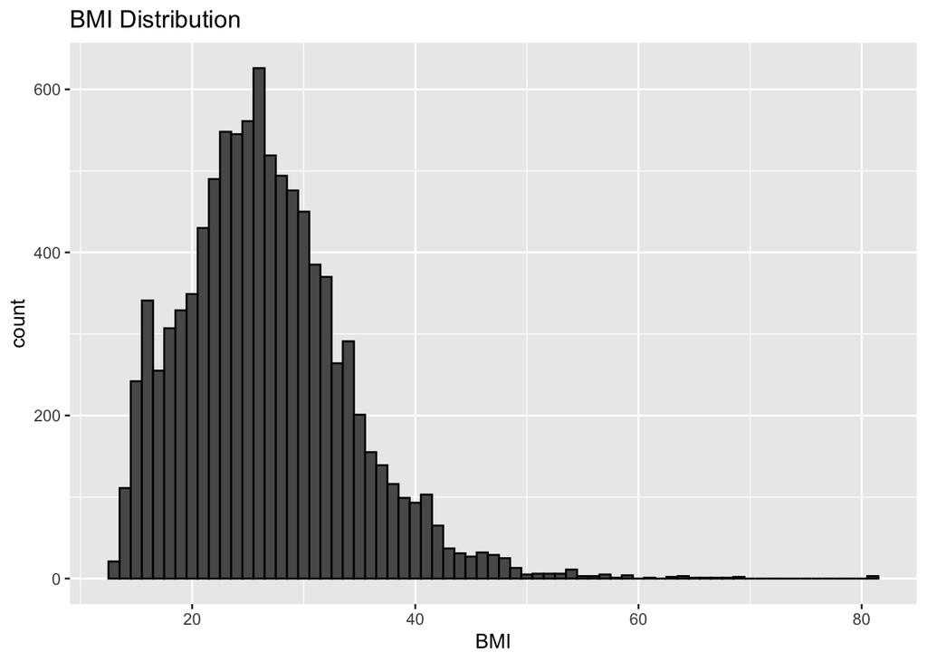

```r
# Plot histograms for each continuous variable
NHANES %>% ggplot(aes(x = BMI)) +
  geom_histogram(binwidth = 1, color = "black") +
  labs(title = "BMI Distribution")
```

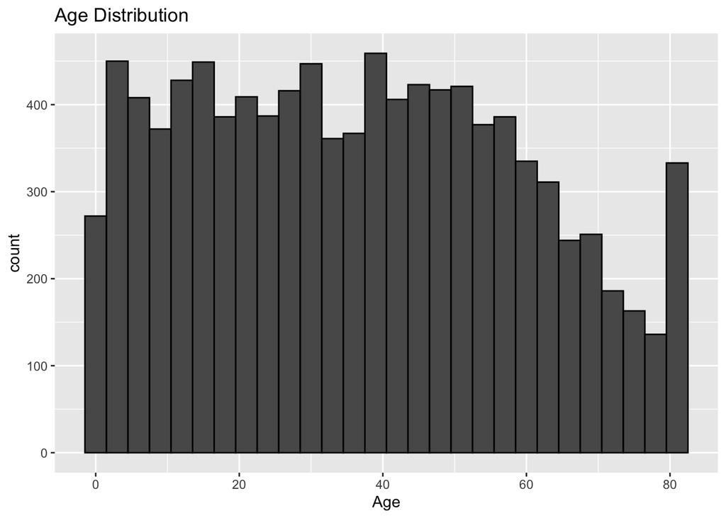

```r
NHANES %>% ggplot(aes(x = Age)) +
  geom_histogram(binwidth = 3, color = "black") +
  labs(title = "Age Distribution")
```

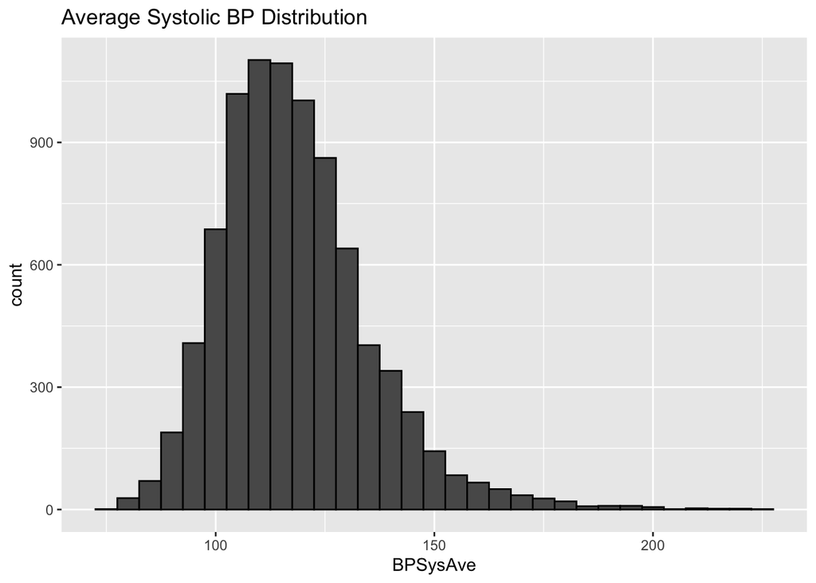

```r
NHANES %>% ggplot(aes(x = BPSysAve)) +
  geom_histogram(binwidth = 5, color = "black") +
  labs(title = "Average Systolic BP Distribution")
```

In the `tableone` package, we can specify which statistical tests to use for different variables. Let’s define:

- **BMI**: Assume non-normally distributed (Wilcoxon test).
- **Age**: Assume normally distributed (t-test).
- **BPSysAve**: Assume non-normally distributed (Wilcoxon test).

```r
# Define continuous and categorical variables
continuous_vars <- c("Age", "BMI", "BPSysAve")
categorical_vars <- c("Gender", "Education")

# Create a custom list of tests based on normality assumptions
test_list <- list(
  BMI = "wilcox.test",      # Non-normally distributed: Wilcoxon test
  Age = "t.test",           # Normally distributed: t-test
  BPSysAve = "wilcox.test"  # Non-normally distributed: Wilcoxon test
)

# Create the summary table stratified by smoking status with custom tests
table_with_custom_tests <- CreateTableOne(
  vars = c(continuous_vars, categorical_vars),
  strata = "SmokeNow",
  data = NHANES,
  factorVars = categorical_vars,
  test = TRUE,
  testExact = test_list,
  addOverall = TRUE
)

print(table_with_custom_tests, showAllLevels = TRUE)
```

```
##                       Stratified by SmokeNow
##                        level          Overall        No
##   n                                    10000           1745
##   Age (mean (SD))                      36.74 (22.40)  54.28 (16.64)
##   BMI (mean (SD))                      26.66 (7.38)   29.09 (6.19)
##   BPSysAve (mean (SD))                118.15 (17.25) 124.38 (18.19)
##   Gender (%)           female           5020 (50.2)     764 (43.8)
##                        male             4980 (49.8)     981 (56.2)
##   Education (%)        8th Grade         451 ( 6.2)     122 ( 7.0)
##                        9 - 11th Grade    888 (12.3)     198 (11.3)
##                        High School      1517 (21.0)     367 (21.0)
##                        Some College     2267 (31.4)     552 (31.6)
##                        College Grad     2098 (29.1)     506 (29.0)
##                       Stratified by SmokeNow
##                        Yes            p      test
##   n                      1466
##   Age (mean (SD))       42.68 (14.79) <0.001
##   BMI (mean (SD))       27.70 (6.42)  <0.001
##   BPSysAve (mean (SD)) 120.12 (17.38) <0.001
##   Gender (%)              638 (43.5)   0.910
##                           828 (56.5)
##   Education (%)            95 ( 6.5)  <0.001
##                           328 (22.4)
##                           388 (26.5)
##                           476 (32.5)
##                           178 (12.2)
```

This is good, but the mean and standard deviation are still being displayed for the non-normal variables. We can get the median and interquartile range (IQR) to be displayed instead by using the `nonnormal` argument in the `print` function. Here I’m saving the non-normally distributed variables as a list called `nonNormalVars`. I’m also setting the number of decimal places to display with `pDigits = 3`.

```r
# Define list of non-normal variables
nonNormalVars <- c("BMI", "BPSysAve")

# Print the table with custom tests and p-values
print(table_with_custom_tests, showAllLevels = TRUE, nonnormal = nonNormalVars, pDigits = 3)
```

```
##                          Stratified by SmokeNow
##                           level          Overall
##   n                                       10000
##   Age (mean (SD))                         36.74 (22.40)
##   BMI (median [IQR])                      25.98 [21.58, 30.89]
##   BPSysAve (median [IQR])                116.00 [106.00, 127.00]
##   Gender (%)              female           5020 (50.2)
##                           male             4980 (49.8)
##   Education (%)           8th Grade         451 ( 6.2)
##                           9 - 11th Grade    888 (12.3)
##                           High School      1517 (21.0)
##                           Some College     2267 (31.4)
##                           College Grad     2098 (29.1)
##                          Stratified by SmokeNow
##                           No                      Yes
##   n                         1745                    1466
##   Age (mean (SD))          54.28 (16.64)           42.68 (14.79)
##   BMI (median [IQR])       28.29 [24.78, 32.30]    26.59 [23.00, 31.50]
##   BPSysAve (median [IQR]) 122.00 [112.00, 134.00] 118.00 [109.00, 127.00]
##   Gender (%)                 764 (43.8)              638 (43.5)
##                              981 (56.2)              828 (56.5)
##   Education (%)              122 ( 7.0)               95 ( 6.5)
##                              198 (11.3)              328 (22.4)
##                              367 (21.0)              388 (26.5)
##                              552 (31.6)              476 (32.5)
##                              506 (29.0)              178 (12.2)
##                          Stratified by SmokeNow
##                           p      test
##   n
##   Age (mean (SD))         <0.001
##   BMI (median [IQR])      <0.001 nonnorm
##   BPSysAve (median [IQR]) <0.001 nonnorm
##   Gender (%)               0.910
##
##   Education (%)           <0.001
##
##
##
##
```

### Step 4: Export the Table to Word

Now, we’ll export the table to a Word document using the `flextable` package. We first have to convert our printed table to a data frame.

```r
# Convert the printed table to a data frame
table_with_custom_tests <- as.data.frame(print(table_with_custom_tests, showAllLevels = TRUE, nonnormal = nonNormalVars, pDigits = 3))
```

```
##                          Stratified by SmokeNow
##                           level          Overall
##   n                                       10000
##   Age (mean (SD))                         36.74 (22.40)
##   BMI (median [IQR])                      25.98 [21.58, 30.89]
##   BPSysAve (median [IQR])                116.00 [106.00, 127.00]
##   Gender (%)              female           5020 (50.2)
##                           male             4980 (49.8)
##   Education (%)           8th Grade         451 ( 6.2)
##                           9 - 11th Grade    888 (12.3)
##                           High School      1517 (21.0)
##                           Some College     2267 (31.4)
##                           College Grad     2098 (29.1)
##                          Stratified by SmokeNow
##                           No                      Yes
##   n                         1745                    1466
##   Age (mean (SD))          54.28 (16.64)           42.68 (14.79)
##   BMI (median [IQR])       28.29 [24.78, 32.30]    26.59 [23.00, 31.50]
##   BPSysAve (median [IQR]) 122.00 [112.00, 134.00] 118.00 [109.00, 127.00]
##   Gender (%)                 764 (43.8)              638 (43.5)
##                              981 (56.2)              828 (56.5)
##   Education (%)              122 ( 7.0)               95 ( 6.5)
##                              198 (11.3)              328 (22.4)
##                              367 (21.0)              388 (26.5)
##                              552 (31.6)              476 (32.5)
##                              506 (29.0)              178 (12.2)
##                          Stratified by SmokeNow
##                           p      test
##   n
##   Age (mean (SD))         <0.001
##   BMI (median [IQR])      <0.001 nonnorm
##   BPSysAve (median [IQR]) <0.001 nonnorm
##   Gender (%)               0.910
##
##   Education (%)           <0.001
##
##
##
##
```

```r
# Convert the table to a flextable object
table_word <- flextable(table_with_custom_tests)

# Save the table as a Word document
flextable::save_as_docx(table_word, path = "nhanes_summary_table.docx")
```

A Word document named `nhanes_summary_table.docx` will be saved to your working directory.

### Important things to note

- You can also save the table as a .csv file and then copy and paste that into a Word document.
- `CreateTableOne` automatically removes missing values of the stratified variable. For example, we started with 10,000 individuals in the overall NHANES sample (and can see n = 10,000 in the Overall column in the table), but that the total number of smokers and non-smokers sums to 3,211. All of the NAs were ignored when stratifying. This is the default behavior, but you can include the argument `includeNA = TRUE` to include missing values.
- You can also export the table to LaTeX using the `kableExtra` package.
- There are other packages you can use to create and export tables in RStudio, including `rempsyc`, `stargazer`, `gt`, etc. [Check out this resource for more](https://bookdown.org/yihui/rmarkdown-cookbook/table-other.html).
- The `tableone` package has other functions that allow you to create tables for continuous variables only or categorical variables only. [Check out the documentation file](https://cran.r-project.org/web/packages/tableone/tableone.pdf).
- Another resource for `tableone` is [here](https://ehsanx.github.io/intro2R/data-summary-with-tableone.html).